# Финансовая устойчивость государственных вузов

Центр институционального анализа науки и образования

[figure not shown]

[figure not shown]

# Введение

Министерство экономического развития [прогнозирует](https://ria.ru/20200521/1571810701.html) снижение реальных доходов населения на 3,8%, это опустит уровень среднего богатства до показателей 2011 года. Согласно недавнему [опросу](https://www.rbc.ru/economics/07/07/2020/5eff14959a794725e351de43), каждый пятый в России заявил о значительном падении дохода из-за пандемии. В этой работе мы хотим рассмотреть финансовые риски, с которыми могут столкнуться российские вузы в ближайшее время из-за падения доходов населения и фирм.

Оценка финансовой устойчивости – это стандартная процедура для фирм и один из ее базовых элементов – оценка соотношения собственных и заемных средств. В контексте государственных вузов нам будет интересно посмотреть на источники доходов вузов – соотношение средств, которые вузы зарабатывают сами, и средств, выделенных из бюджетов всех уровней.

Исследования показывают, что в России прием студентов в вузы зависит от платежеспособности населения [(Филатова 2014](https://publications.hse.ru/view/134756188); [Абанкина 2013](https://publications.hse.ru/chapters/102675499)). В период кризиса 2007-2008 гг. именно высокодоходные семьи, которые составляют основной источник спроса на высшее образование, снизили свои расходы на высшее образование. Еще до пандемии наблюдалось сокращение расходов домохозяйств на высшее образование – особенно после 2010 года [(Абанкина 2013)](https://publications.hse.ru/chapters/102675499).

Таким образом, снижение платежеспособности населения и фирм может создать существенные риски для вузов. В этом исследовании мы попытаемся ответить на следующие вопросы:

1. Какая доля доходов вузов потенциально может оказаться под угрозой из-за падения доходов фирм и населения?
2. Что объединяет вузы, которые попадают в зону риска?
3. Какие виды расходов финансируются за счет доходов, полученных от населения и фирм?
4. Возможно, ли будет перераспределить доходы так, чтобы не сокращать особо чувствительные статьи расходы, например, оплату труда?

# Данные

На официальном сайте с информацией о государственных (муниципальных) учреждениях bus.gov.ru публикуются отчеты о финансовых результатах деятельности вузов. В них содержаться данные о доходах и расходах вузов. Мы получили отчеты 390 государственных вузов за 2018 год (за этот год доступны наиболее полные данные). Всего в 2018 году в России насчитывалось 502 государственных вуза (без филиалов). Помимо очевидной проблемы, что не все государственные вузы публикуют эти отчеты, существует проблема качества их заполнения – то есть, отчет может быть загружен на сайт, но его содержание вызывает вопросы. Например, Чурапчинский государственный институт физической культуры и спорта подробно расписывает строки доходов, при это раздел расходов оставляет пустым. Такие вузы с неполными или вызывающими вопросы отчетами мы тоже исключили из нашей выборки. При этом мы не обнаружили какого-либо смещения по регионам или семействам для вузов, которые не опубликовали отчет или опубликовали с потенциальными ошибками. То есть, мы предполагаем, вузы не попали в нашу выборку случайным образом, как минимум, по региональному признаку и принадлежности к семейству (Таблица 1).

##### Таблица 1. Сопоставление выборки и генеральной совокупности по семействам, 2018 год

| Семейство | Кол-во вузов в выборке | % в выборке | Кол-во вузов в ген.совок. | % в ген.совок. |
| --- | --- | --- | --- | --- |
| Аграрные | 46 | 11.8 | 54 | 10.8 |
| Классические | 65 | 16.7 | 85 | 16.9 |
| Культуры и искусств | 43 | 11.0 | 55 | 11.0 |
| Медицинские | 35 | 9.0 | 46 | 9.2 |
| Муниципальные | 39 | 10.0 | 43 | 8.6 |
| Педагогические | 24 | 6.2 | 31 | 6.2 |
| Силовые и спортивные | 11 | 2.8 | 14 | 2.8 |
| Социальные и гуманитарные | 32 | 8.2 | 36 | 7.2 |
| Технические | 95 | 24.4 | 124 | 24.7 |
| Семейство не определено | NA | NA | 14 | 2.8 |
| Всего | 390 | 100.0 | 502 | 100.0 |

Немного подробнее о самих отчетах: они имеют матричную структуру (образец упрощенной формы представлен в Приложении 2). В отчете мы можем видеть не только общую сумму доходов по различным статьям, но и источник финансирования этих доходов. То есть, мы можем видеть, что вуз оказал услуг на 100 рублей, при этом, 60 рублей получил из бюджета, а 40 рублей из внебюджетных источников (фирмы и население). То же самое и с расходами – мы видим, что вуз заплатил сотрудникам 100 рублей, и мы точно знаем, какая часть из этих 100 рублей это бюджетные деньги, а какая внебюджетные. Основным ограничением для нас является то, что доходы и расходы разбиты на укрупненные группы, поэтому мы не можем узнать о содержании, например, строки “Доходы от оказания платных услуг”. Внутри будет находится не только образовательная деятельность вуза, но и научная. Таким образом, мы будем знать, откуда пополнялась эта строка – из бюджета или от фирм/населения, но не будем знать что там доходы от образовательных программ, а что доходы от научных исследований.

Теперь подробнее о нашей выборке в 390 вузов. Распределение доходов среднего вуза представлено схематично в Таблице 2. Внебюджетные доходы составляют 37% от всех доходов вуза, причем основная часть внебюджетных доходов – это доходы от оказания платных услуг (90%), то есть деньги студентов и фирм за образование услуги и научные исследования. Остаются еще 10% куда входят доходы от собственности, возмещение ущерба, операции с активами и прочее.

##### Таблица 2. Распределение доходов среднего вуза в нашей выборке

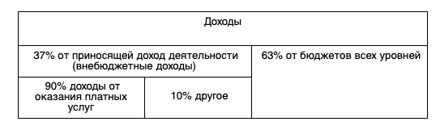

*Примечание: Формулировкой “бюджеты всех уровней” здесь и далее мы объединяем два источника финансирования: “Деятельность по государственному заданию” и “Деятельность с целевыми средствами”.*

В нашей выборке есть вузы, которые сильно отклоняются от средних значений (см. Таблицу 3). Например, есть вуз, у которого зафиксирована минимальная доля доходов от приносящей доход деятельности – 2,1%, это значит, что все остальные доходы он получает от бюджетов всех уровней. Еще есть вуз для которого 99,1 % доходов – это внебюджетные средства, а значит только 0,9 % этот вуз получает из бюджета. При этом такие выбросы, по всей видимости, не вносят сильного шума, так как среднее и медиана почти совпадают. Если смотреть на квартили, то мы видим, что для четверти вузов в нашей выборке доля внебюджетных доходов составляет более 47,3%.

##### Таблица 3. Описательные статистики доходов вузов

|  | n | min | max | Q1 | Q3 | mean | madian |
| --- | --- | --- | --- | --- | --- | --- | --- |
| Доходы.от.бюджетов.всех.уровней | 390 | 0.87 | 97.87 | 52.75 | 75.36 | 63.25 | 64.72 |
| Доходы.от.приносящ..доход.деятельн. | 390 | 2.13 | 99.13 | 24.64 | 47.25 | 36.75 | 35.28 |

Сразу ограничим область наших интересов: **нас интересуют не просто внебюджетные доходы вузов, а только доходы от оказания платных услуг**. То есть мы будем смотреть на блок 90% из Таблицы 2 и при этом игнорировать 10%-ый блок “Другое”, с доходами от собственности, операции с активами и прочим. Делаем мы это потому, что доходы от платных услуг населению и фирмам можно легко интерпретировать. В первую очередь это доходы от коммерческих студентов, выполнение научных исследований для сторонних организаций, программы дополнительного образования, повышения квалификации и прочее.

# Доходы вузов

##### Рис. 1. Распределение вузов по доходам от платных услуг населению и фирмам

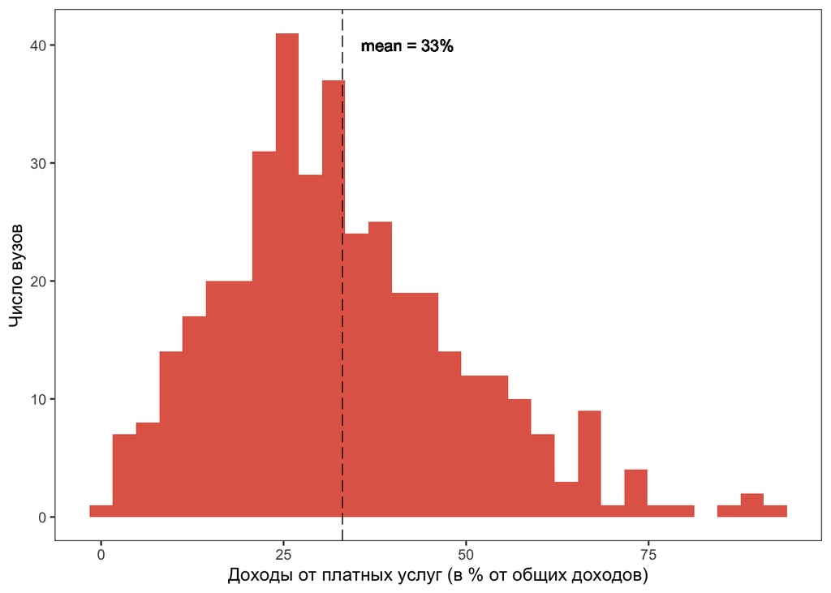

### Рубли и проценты

Посмотрим на доходы вузов в абсолютных цифрах и процентах. Очевидно, что 30% от общих доходов для крупного столичного вуза и для региональной академии культуры – это не одна и та же сумма в рублях. В первой десятке по абсолютным значениям мы видим заметный разброс (Табл. 4). К примеру, один из лидеров по абсолютным значениям – Высшая школа экономики с 7363 млн. руб внебюджетных доходов от услуг населению и фирмам, но в процентах это лишь треть от всех доходов вуза (34%), тогда как для РУДН сопоставимая сумма в рублях составляет почти две трети доходов (60%).

##### Таблица 4. Внебюджетные доходы от платных услуг населению и фирмам

[interactive table not shown]

Если мы посмотрим на все вузы в нашей выборке, то мы увидим прямую зависимость (Рис. 2). Вузы, которые оперируют бóльшими суммами в рублях имеют бóльшую долю доходов от платных услуг. Вузы, которые оперируют меньшими суммами будут сильнее зависеть от государственных денег.

##### Рис. 2. Соотношение доли доходов от платных услуг с абсолютным их выражением в рублях

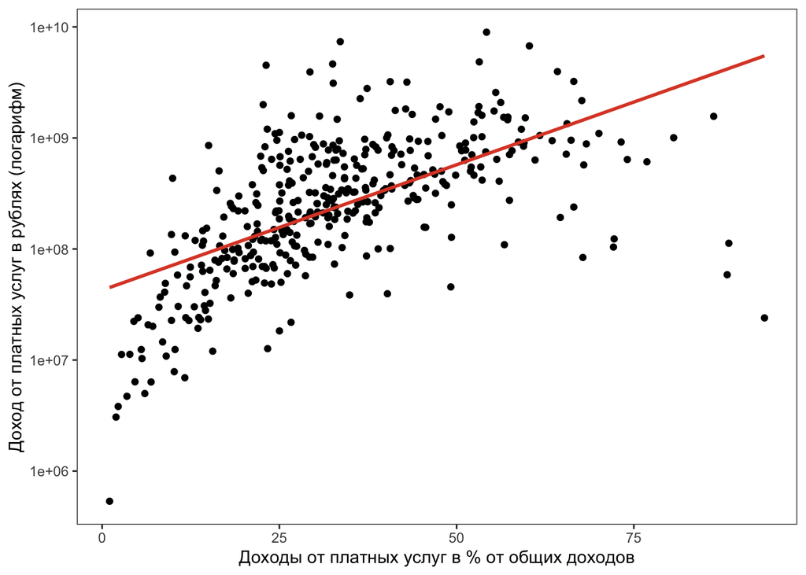

Возникает вопрос: что объединяет вузы, у которых получается зарабатывать самостоятельно. Мы проверим региональный признак и принадлежность к семейству.

### Семейства и регионы

У социальных и гуманитарных вузов в среднем доля доходов от оказания платных услуг населению и фирмам составляет 55%, у медицинских – 48% . Хуже всего “зарабатывают” силовые, спортивные, вузы культуры и искусств. Самые многочисленные семейства вузов – технические и классические – в среднем получают треть своих доходов от платных услуг населению и фирмам.

##### Рис. 3. Доходы от платных услуг населению и фирмам: среднее по семействам

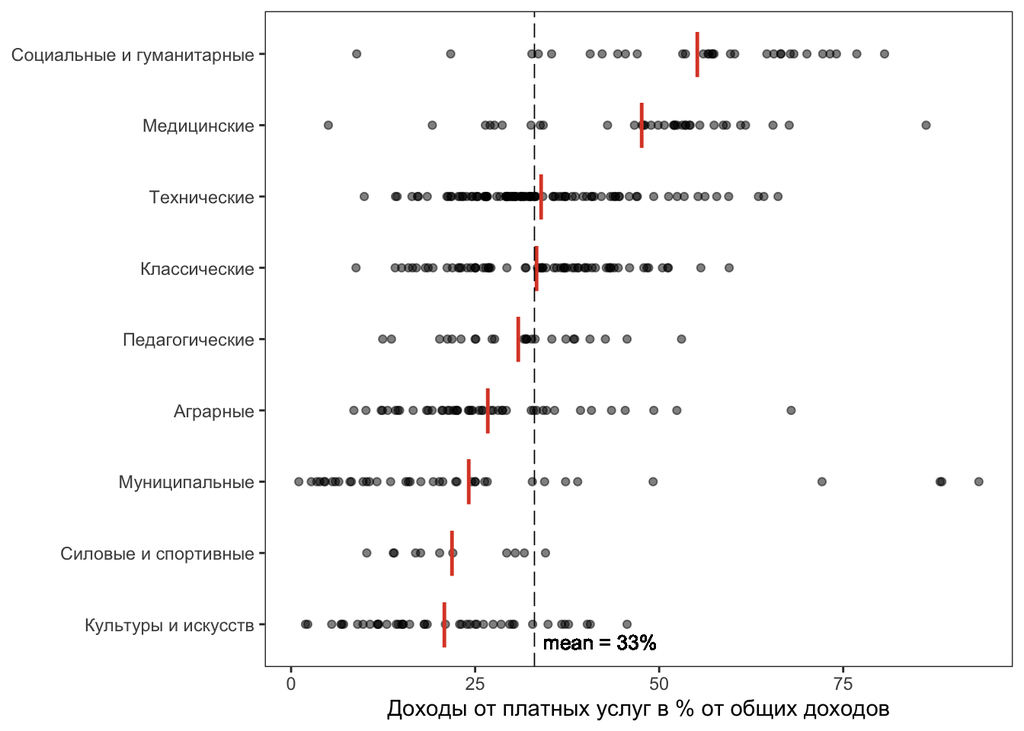

В Приложении 3 приведены отдельные таблицы с названиями конкретных вузов, которые имеют самые высокие цифры по собственным доходам, отдельно в абсолютных значениях и отдельно и долях, а мы рассмотрим семейства более детально через описательные статистики.

##### Таблица 5. Доходы от платных услуг населению и фирмам (в % от общих доходов)

| Семейство | mean | madian | Var | n | Q1 | Q3 |
| --- | --- | --- | --- | --- | --- | --- |
| Социальные и гуманитарные | 55.2 | 57.2 | 272.6 | 32 | 45.2 | 66.8 |
| Медицинские | 47.6 | 51.9 | 240.1 | 35 | 38.6 | 54.9 |
| Технические | 34.0 | 31.6 | 132.8 | 95 | 26.5 | 40.5 |
| Классические | 33.4 | 34.2 | 126.4 | 65 | 24.9 | 40.9 |
| Педагогические | 30.9 | 31.9 | 96.1 | 24 | 24.5 | 37.6 |
| Аграрные | 26.8 | 24.6 | 141.6 | 46 | 19.5 | 32.9 |
| Муниципальные | 24.2 | 17.6 | 573.4 | 39 | 8.1 | 26.5 |
| Силовые и спортивные | 21.9 | 20.2 | 69.2 | 11 | 15.5 | 29.9 |
| Культуры и искусств | 20.9 | 18.5 | 128.3 | 43 | 11.8 | 29.1 |
| Всего по всем вузам | 33.1 | 31.2 | 281.8 | 390 | 21.9 | 42.9 |

Практически для всех типов вузов медиана близка к среднему значению – внутри семейств нет сильно заметного разброса по доли внебюджетных доходов от платных услуг (за исключением муниципальных вузов). Если в среднем социально-гуманитарные вузы зарабатывают больше остальных вузов, то это свойственно почти всем вузам этого типа (для 75% социально-гуманитарных вузов характерна доля собственных доходов больше 45%).

Далее разобьем вузы по двум группам: столичные вузы (Москва и Санкт-Петербург) и региональные вузы (остальные регионы России). Повторим тот же график как на рис. 2, но с учетом этой группировки.

##### Рис. 4. Соотношение доли доходов от платных услуг с абсолютным их выражением в рублях по группам регионов

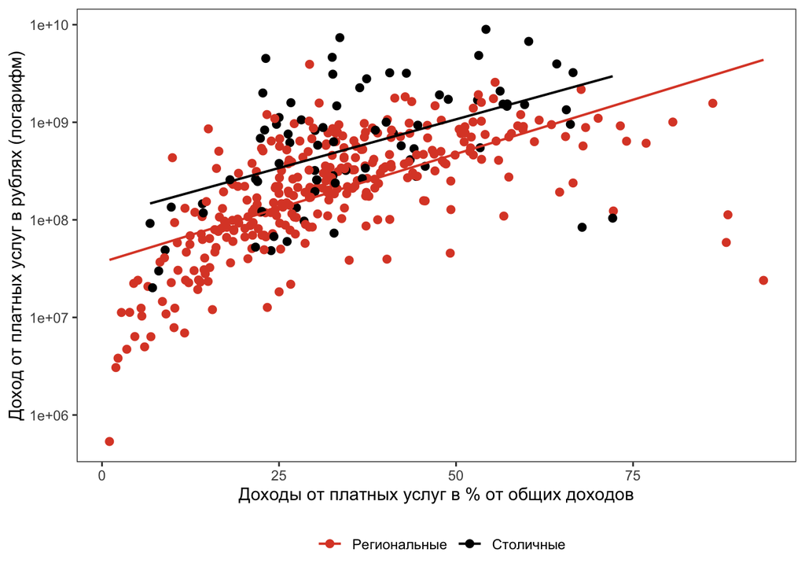

На рис. 4 мы видим, что облако столичных вузов в основном перемешано с облаком региональных, но всю верхнюю область этого облака занимают преимущественно черные точки, т.е. столичные вузы. Таким образом, когда мы говорим о вузах с самыми большими доходами от оказания платных услуг населению (в рублях), то это Москва и Санкт-Петербург, но когда мы смотрим на доли в общих доходах, то средний столичный вуз мало чем отличаются от среднего регионального по способности зарабатывать на платных услугах населению и фирмам.

##### Таблица 6. Доходы от платных услуг населению и фирмам (в % от общих доходов): регионы

|  | Регионы | Среднее | Медиана | Кол-во вузов |
| --- | --- | --- | --- | --- |
| 1 | Краснодарский край | 51.0564773255152 | 52.4037677361332 | 7 |
| 2 | Республика Башкортостан | 47.2904420435349 | 38.3839391403716 | 7 |
| 3 | Республика Адыгея | 46.1916988872947 | 46.1916988872947 | 2 |
| 4 | Забайкальский край | 43.9257095460587 | 43.9257095460587 | 2 |
| 5 | Калужская область | 43.1574925777036 | 43.1574925777036 | 1 |
| 6 | Тверская область | 41.7759463879197 | 31.1821735411753 | 3 |
| 7 | Республика Коми | 40.8451451126681 | 40.8451451126681 | 2 |
| 8 | Свердловская область | 40.3609600759893 | 38.5258972477771 | 13 |
| 9 | Курская область | 40.3577766699486 | 39.993312988376 | 5 |
| 10 | Нижегородская область | 39.4970298717433 | 41.1041803148029 | 8 |

[output cut: 69 more lines]

# Расходы вузов

В среднем бюджеты вузов сбалансированы, то есть все полученные доходы вуз направляет на финансирование своих расходов, и в первую очередь на оплату труда. Нас далее будут интересовать только расходы, которые вуз финансируются за счет внебюджетных средств. Такие расходы вузов мы разделим на три группы: (1) оплата труда (зарплата и прочие начисления); (2) оплата работ и услуг (связь, транспорт, коммунальные платежи и др.); (3) прочее (пособия по социальной помощи населению и др.).

##### Рис. 5. Распределение расходов, финансируемых приносящей доход деятельностью

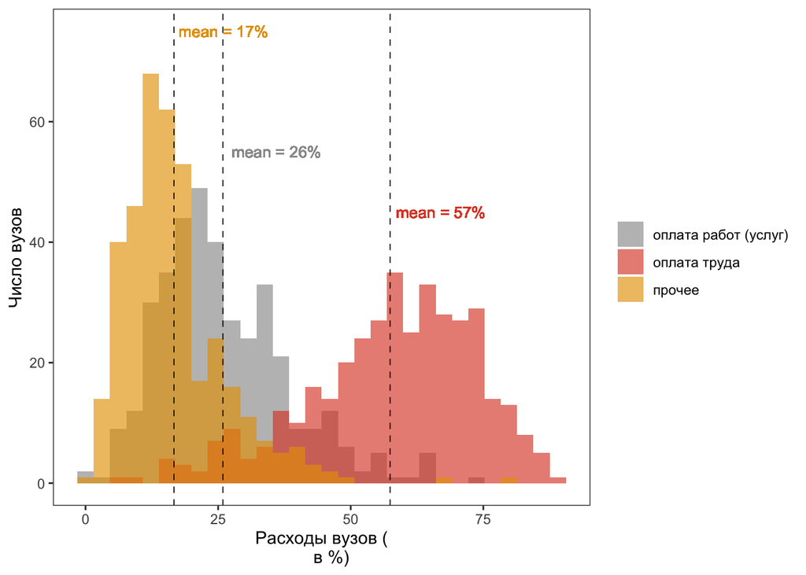

На Рис.5 показаны распределения по всем трем типам расходов. В среднем, оплата труда составляет 57% всех расходов, финансируемых приносящей доход деятельностью. Эту статью расходов можно назвать наиболее чувствительной. В случае сокращения доходов от приносящей доход деятельности, именно ее урезание приведет либо к увольнению сотрудников вузов, либо к сокращению их доходов.

Напомним, что деньги от приносящей доход деятельности – это не только деньги студентов и фирм. Для нас эта деталь очень важна. Чтобы понять возможно ли перераспределить доходы так, чтобы не сокращать особо чувствительные статьи, например, оплату труда, далее мы будем работать только с 359 вузами, а не с 390 как раньше. Мы вынуждены убрать из анализа вузы двух типов: вузы, которые вообще не финансируют оплату труда деньгами студентов и фирм (12 вузов из 31), а также вузы, у которых серьезная часть доходов отражается по строке “Доходы от собственности” или вообще как Прочие доходы от приносящей доход деятельности (19 вузов).

На урезанной выборке в 359 вузов посмотрим на те, которые финансируют большую часть расходов на оплату труда из денег студентов-платников и фирм.

##### Таблица 8. Расходы на оплату труда, финансируемые за счет студентов и фирм

[interactive table not shown]

Из Таблицы 8 мы видим, что Воронежский институт экономики и социального управления потратил на оплату труда 25 млн руб, из которых как минимум 23 млн руб – деньги студентов и фирм, а 2 млн руб – это все остальные деньги (от бюджетов всех уровней, от собственности, операций с активами и тд). То есть эта таблица по сути это топ вузов, у которых самая чувствительная статья расходов – оплата труда, финансируется за счет не самого стабильного источника – доходами от платных услуг населению и фирмам.

Посмотрим что объединяет вузы, которые направляют внебюджетные доходы от платных услуг главным образом на оплату труда. Таблица 9 содержит описательные статистики для каждого семейства.

Социально-гуманитарные и медицинские вузы больше остальных типов вузов получают доходы от платных услуг, однако, они и больше остальных вузов направляют их на оплату труда – в среднем не менее 35% для первых и 30 для вторых. Другие типы вузов в основном оплату труда производят за счет бюджетного финансирования, что наиболее характерно для вузов культуры и искусств, а также силовых и спортивных вузов.

##### Таблица 9. Расходы на оплату труда, от платных услуг населению и фирмам по типам вузов (% от общих расходов вуза)

| Семейство | mean | madian | Var | n | Q1 | Q3 |
| --- | --- | --- | --- | --- | --- | --- |
| Социальные и гуманитарные | 35.0 | 38.9 | 171.8 | 30 | 26.0 | 42.9 |
| Медицинские | 30.3 | 30.8 | 70.1 | 35 | 25.3 | 36.5 |
| Технические | 19.1 | 17.4 | 100.0 | 89 | 12.7 | 23.8 |
| Муниципальные | 18.8 | 12.5 | 412.8 | 33 | 3.3 | 23.0 |
| Классические | 17.8 | 17.2 | 72.7 | 65 | 11.7 | 23.9 |
| Педагогические | 15.6 | 13.3 | 81.7 | 21 | 8.5 | 21.5 |
| Аграрные | 13.7 | 12.4 | 64.7 | 40 | 9.7 | 17.5 |
| Культуры и искусств | 11.1 | 8.8 | 67.0 | 36 | 5.3 | 16.2 |
| Силовые и спортивные | 10.8 | 10.5 | 38.4 | 10 | 6.6 | 15.9 |
| Всего по всем вузам | 19.4 | 17.2 | 160.3 | 359 | 10.3 | 25.4 |

## Возможно, ли будет перераспределить доходы так, чтобы не сокращать особо чувствительные статьи расходов?

Нам интересна оплата труда, которая финансируется за счет студентов и фирм. Если у вуза снижается поток доходов из этого источника, то придется либо урезать оплату труда, либо перекидывать из других статей расходов.

Таким образом нам интересно посмотреть на вузы, которые имеют самые большие расходы на оплату труда из денег студентов и фирм при этом у них самая маленькая величина всех остальных расходов, которые финансируются уже откуда угодно - бюджетом, доходами от собственности и тд, то есть мы ищем вузы, у которых почти нет других статей расходов, откуда потенциально можно было бы перекидывать средства, чтобы перенаправить на зарплату.

##### Таблица 10. Топ вузов с самыми большими расходами на оплату труда из денег студентов и фирм при самой маленькой величине всех остальных расходов (в млн. руб.).

|  | Вуз | Оплата труда, финансируемая студентами и фирмами (млн руб) [2] | Все остальные расходы из всех источников кроме расходов на оплату труда (млн руб) [3] | Доля [3] к [2] (%) | Расходы на зарплату из всех источников (млн руб) | Все расходы из всех источников (млн руб) |
| --- | --- | --- | --- | --- | --- | --- |
| 1 | краснодарский муниципальный медицинский институт высшего сестринского образования | 53.7563149 | 12.12350089 | 22.552700854872 | 58.92327896 | 71.04677985 |
| 2 | московский государственный медико-стоматологический университет имени а.и. евдокимова министерства здравоохранения российской федерации | 1593.96875282 | 643.53029824 | 40.3728302139854 | 3417.25111607 | 4060.78141431 |
| 3 | московский государственный институт индустрии туризма имени ю.а. сенкевича | 69.88094324 | 29.2683115 | 41.8831088176365 | 198.11080244 | 227.37911394 |
| 4 | башкирская академия государственной службы и управления при главе республики башкортостан | 69.27887032 | 29.05950808 | 41.9457014032904 | 79.12361109 | 108.18311917 |
| 5 | воронежский институт экономики и социального управления | 23.21156782 | 10.00664144 | 43.110579679921 | 24.77373679 | 34.78037823 |
| 6 | нижегородский государственный лингвистический университет им. н.а. добролюбова | 219.3548633 | 96.32857256 | 43.914491391174 | 288.70735374 | 385.0359263 |
| 7 | санкт-петербургский государственный институт психологии и социальной работы | 86.70438556 | 38.4744788 | 44.3743168831701 | 113.8364722 | 152.310951 |
| 8 | сибирский государственный университет путей сообщения | 786.41184322 | 351.46461732 | 44.6921826457892 | 1181.3533244 | 1532.81794172 |
| 9 | поволжский государственный университет сервиса | 98.77486763 | 48.80660355 | 49.4119655344154 | 160.15206829 | 208.95867184 |
| 10 | московский архитектурный институт (государственная академия) | 397.93447709 | 212.55999588 | 53.4158280112848 | 772.86576089 | 985.42575677 |

[output cut: 349 more lines]

В Краснодарском муниципальном медицинском институте 54 млн рублей из денег студентов и фирм пошли на оплату труда. Предположим, что вуз недополучит в следующем периоде денег от студентов и фирм, но не захочет увольнять сотрудников или урезать им зарплаты. Тогда можно перенаправить деньги, которые вуз пускал на другие статьи расходов (связь, транспорт, аренда, коммунальные платежи и прочее). Вопрос, а сколько этих денег, которые потенциально можно перенаправить, есть у вуза? У Краснодарского муниципального медицинского института все остальные расходы, не связанные с зарплатой составляют 12 млн руб.

Таким образом, Таблица 10 это фактически топ вузов, у которых возможность какого-либо маневра сведена к минимуму. Если Краснодарский муниципальный медицинский институт недополучит, допустим, 12 млн руб от студентов и фирм, то он сможет не сокращать расходы на оплату труда только при условии, что ни на связь, ни на транспорт ни на всё прочее он вообще не потратит ни рубля.

Таблица 11 показывает, как много вузов с ограниченным маневром для каждого семейства. Всего в нашей выборке мы зафиксировали 14% вузов, которым будет затруднительно перераспределить расходы в случае необходимости восполнить потери внебюджетные доходов от платных услуг. Мы опять видим, что такие вузы чаще встречаются среди категорий вузов с заметной долей внебюджетного финансирования – социально-гуманитарные и медицинские вузы.

##### Таблица 11.

| Семейство | Вузы с ограниченным маневром | Всего вузов в семействе | % вузов в семействе с ограниченным маневром | % покрытия расходов на оплату труда, в случае потери доходов от студентов и фирм для вузов с ограниченным маневром | % покрытия расходов на оплату труда, в случае потери доходов от студентов и фирм для всех вузов |
| --- | --- | --- | --- | --- | --- |
| Муниципальные | 6 | 33 | 18.2 | 42.2 | 8671.0 |
| Культуры и искусств | 1 | 36 | 2.8 | 64.3 | 2673.8 |
| Аграрные | 1 | 40 | 2.5 | 65.4 | 696.8 |
| Педагогические | 1 | 21 | 4.8 | 68.0 | 407.7 |
| Социальные и гуманитарные | 19 | 30 | 63.3 | 69.8 | 199.3 |
| Технические | 10 | 89 | 11.2 | 75.6 | 525.7 |
| Медицинские | 10 | 35 | 28.6 | 78.9 | 141.4 |
| Классические | 4 | 65 | 6.2 | 87.8 | 1477.1 |
| Всего | 52 | 359 | 14.5 | 70.6 | 1620.2 |

# Выводы

Внебюджетные доходы составляют в среднем 37% от всех доходов вуза; только для 25% вузов в нашей выборке доля внебюджетных доходов составляет более 47%.

Большая часть внебюджетных доходов – это доходы от оказания платных услуг по образовательным программам и проведению исследований (в среднем 90% внебюджетных средств).

Вузы, которые оперируют бóльшими суммами в рублях, являются и более независимыми от бюджетных денег (имеют бóльшую долю доходов от платных услуг).

Внебюджетное финансирование распределено неравномерно по типам вузов. У социальных и гуманитарных вузов в среднем доля доходов от оказания платных услуг населению и фирмам составляет 55%, у медицинских – 48%. Хуже всего “зарабатывают” силовые, спортивные, культуры и искусств. Самые многочисленные семейства вузов имеют треть своих доходов из внебюджетных источников – технические и классические вузы.

Внутри семейств нет сильно заметного разброса значений по внебюджетным доходам (за исключением муниципальных вузов). Если в среднем социально-гуманитарные вузы зарабатывают больше остальных вузов, то это свойственно почти всем вузам этого типа, также и наоборот.

Вузы с самыми большими доходами от оказания услуг населению (в рублях) – это чаще столичные вузы; среди региональных вузов больше тех вузов, для которых внебюджетные деньги – это главный доход.

Социально-гуманитарные и медицинские вузы больше остальных типов вузов получают доходы от платных услуг, однако, они и больше остальных вузов направляют их на оплату труда – в среднем не менее 35% для первых и 30 для вторых. Другие типы вузов в основном оплату труда производят за счет бюджетного финансирования, что наиболее характерно для вузов культуры и искусств, а также силовых и спортивных вузов.

Тем самым, те, кто живет на внебюджетные доходы, находятся в зоне риска, так как у них доля расходов на оплату труда выше, а «остаток» для покрытия дополнительных расходов меньше в сравнении с бюджетными по доходам вузами.

Парадоксально, но большей свободой для траты внебюджетных средств обладают, по всей видимости, те вузы, для которых доходы от платных услуг составляют не самую значимую роль, так как основные большие статьи расходов они покрывают за счет бюджетных средств.

# Приложения

##### Приложение 1. Распределение доходов государственных вузов по источникам их получения и видам деятельности, 2019 год

| Источник финансирования | Образовательная деятельность млн.руб. | Образовательная деятельность % | Научные исследования млн.руб. | Научные исследования % | Прочее млн.руб. | Прочее % | Всего (млн.руб) |
| --- | --- | --- | --- | --- | --- | --- | --- |
| бюджеты всех уровней | 404175 | 65 | 42914 | 40 | 93704 | 53 | 540793 |
| организации | 19997 | 3 | 57616 | 54 | 34329 | 19 | 111942 |
| население | 181056 | 29 | 2103 | 2 | 29347 | 16 | 212506 |
| внебюджетные фонды | 613 | 0 | 2932 | 3 | 19408 | 11 | 22953 |
| иностранные источники | 17178 | 3 | 1318 | 1 | 1455 | 1 | 19952 |
| Итого доходов | 623020 | 100 | 106883 | 100 | 178243 | 100 | 908146 |

*Источник: Данные Минобрнауки. ВПО-2 (2019)*

##### Приложение 2. Упрощенная версия отчета о финансовых результатах деятельности

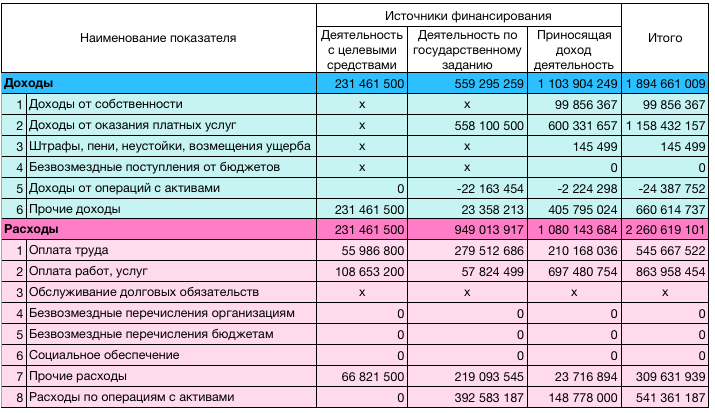

##### Приложение 3. Топ-10 вузов по доходам от платных услуг населению и фирмам: в млн. рублей и в % от общих доходов вуза

###### Социальные и гуманитарные

|  | Топ-10 вузов - Социальные и гуманитарные | в % | Топ-10 вузов - Социальные и гуманитарные | млн. руб |
| --- | --- | --- | --- | --- |
| 1 | УРАЛЬСКИЙ ГОСУДАРСТВЕННЫЙ ЭКОНОМИЧЕСКИЙ УНИВЕРСИТЕТ | 80.6162629150453 | ВЫСШАЯ ШКОЛА ЭКОНОМИКИ | 7363.41543957 |
| 2 | НИНХ | 76.8454096206434 | РОССИЙСКИЙ УНИВЕРСИТЕТ ДРУЖБЫ НАРОДОВ | 6741.14299792 |
| 3 | САМАРСКИЙ ГОСУДАРСТВЕННЫЙ ЭКОНОМИЧЕСКИЙ УНИВЕРСИТЕТ | 74.0818632173451 | РОССИЙСКИЙ ЭКОНОМИЧЕСКИЙ УНИВЕРСИТЕТ ИМЕНИ Г.В. ПЛЕХАНОВА | 4838.16777267 |
| 4 | САРАТОВСКАЯ ГОСУДАРСТВЕННАЯ ЮРИДИЧЕСКАЯ АКАДЕМИЯ | 73.2041806566496 | МОСКОВСКИЙ ГОСУДАРСТВЕННЫЙ ИНСТИТУТ МЕЖДУНАРОДНЫХ ОТНОШЕНИЙ (УНИВЕРСИТЕТ) МИНИСТЕРСТВА ИНОСТРАННЫХ ДЕЛ РОССИЙСКОЙ ФЕДЕРАЦИИ | 3226.60792829 |
| 5 | ОРЛОВСКИЙ ГОСУДАРСТВЕННЫЙ УНИВЕРСИТЕТ ЭКОНОМИКИ И ТОРГОВЛИ | 72.2202065673084 | ФИНАНСОВЫЙ УНИВЕРСИТЕТ ПРИ ПРАВИТЕЛЬСТВЕ РОССИЙСКОЙ ФЕДЕРАЦИИ | 3211.88837151 |
| 6 | ВЛАДИВОСТОКСКИЙ ГОСУДАРСТВЕННЫЙ УНИВЕРСИТЕТ ЭКОНОМИКИ И СЕРВИСА | 70.070304112892 | САНКТ-ПЕТЕРБУРГСКИЙ ГОСУДАРСТВЕННЫЙ ЭКОНОМИЧЕСКИЙ УНИВЕРСИТЕТ | 1539.75206059 |
| 7 | РОСТОВСКИЙ ГОСУДАРСТВЕННЫЙ ЭКОНОМИЧЕСКИЙ УНИВЕРСИТЕТ (РИНХ) | 68.2991290441429 | РОССИЙСКИЙ ГОСУДАРСТВЕННЫЙ ГУМАНИТАРНЫЙ УНИВЕРСИТЕТ | 1533.72564727 |
| 8 | РОССИЙСКАЯ ГОСУДАРСТВЕННАЯ АКАДЕМИЯ ИНТЕЛЛЕКТУАЛЬНОЙ СОБСТВЕННОСТИ | 67.8079624268346 | РОССИЙСКИЙ ГОСУДАРСТВЕННЫЙ СОЦИАЛЬНЫЙ УНИВЕРСИТЕТ | 1516.51840004 |
| 9 | НИЖЕГОРОДСКИЙ ГОСУДАРСТВЕННЫЙ ЛИНГВИСТИЧЕСКИЙ УНИВЕРСИТЕТ ИМ. Н.А. ДОБРОЛЮБОВА | 66.5272678581502 | МОСКОВСКИЙ ГОСУДАРСТВЕННЫЙ ЮРИДИЧЕСКИЙ УНИВЕРСИТЕТ ИМЕНИ О.Е. КУТАФИНА (МГЮА) | 1457.5215002 |
| 10 | МОСКОВСКИЙ ГОСУДАРСТВЕННЫЙ ИНСТИТУТ МЕЖДУНАРОДНЫХ ОТНОШЕНИЙ (УНИВЕРСИТЕТ) МИНИСТЕРСТВА ИНОСТРАННЫХ ДЕЛ РОССИЙСКОЙ ФЕДЕРАЦИИ | 66.5244396580084 | ВСЕРОССИЙСКИЙ ГОСУДАРСТВЕННЫЙ УНИВЕРСИТЕТ ЮСТИЦИИ (РПА МИНЮСТА РОССИИ) | 1342.51654094 |

###### Медицинские

|  | Топ-10 вузов - Медицинские | в % | Топ-10 вузов - Медицинские | млн. руб |
| --- | --- | --- | --- | --- |
| 1 | ВОЛГОГРАДСКИЙ ГОСУДАРСТВЕННЫЙ МЕДИЦИНСКИЙ УНИВЕРСИТЕТ МИНИСТЕРСТВА ЗДРАВООХРАНЕНИЯ РОССИЙСКОЙ ФЕДЕРАЦИИ | 86.2623582951448 | МОСКОВСКИЙ ГОСУДАРСТВЕННЫЙ МЕДИЦИНСКИЙ УНИВЕРСИТЕТ ИМЕНИ И.М. СЕЧЕНОВА | 8954.47276473 |
| 2 | БАШКИРСКИЙ ГОСУДАРСТВЕННЫЙ МЕДИЦИНСКИЙ УНИВЕРСИТЕТ МИНИСТЕРСТВА ЗДРАВООХРАНЕНИЯ РОССИЙСКОЙ ФЕДЕРАЦИИ | 67.6666856001968 | ПЕРВЫЙ САНКТ-ПЕТЕРБУРГСКИЙ ГОСУДАРСТВЕННЫЙ МЕДИЦИНСКИЙ УНИВЕРСИТЕТ ИМЕНИ АКАДЕМИКА И.П. ПАВЛОВА МИНИСТЕРСТВА ЗДРАВООХРАНЕНИЯ РОССИЙСКОЙ ФЕДЕРАЦИИ | 3180.51455589 |
| 3 | ТВЕРСКОЙ ГОСУДАРСТВЕННЫЙ МЕДИЦИНСКИЙ УНИВЕРСИТЕТ МИНИСТЕРСТВА ЗДРАВООХРАНЕНИЯ РОССИЙСКОЙ ФЕДЕРАЦИИ | 65.4652713085456 | РОССИЙСКИЙ НАЦИОНАЛЬНЫЙ ИССЛЕДОВАТЕЛЬСКИЙ МЕДИЦИНСКИЙ УНИВЕРСИТЕТ ИМЕНИ Н.И. ПИРОГОВА МИНИСТЕРСТВА ЗДРАВООХРАНЕНИЯ РОССИЙСКОЙ ФЕДЕРАЦИИ | 3109.10157126 |
| 4 | ИРКУТСКИЙ ГОСУДАРСТВЕННЫЙ МЕДИЦИНСКИЙ УНИВЕРСИТЕТ МИНИСТЕРСТВА ЗДРАВООХРАНЕНИЯ РОССИЙСКОЙ ФЕДЕРАЦИИ | 61.7360918431366 | САРАТОВСКИЙ ГОСУДАРСТВЕННЫЙ МЕДИЦИНСКИЙ УНИВЕРСИТЕТ ИМЕНИ В.И.РАЗУМОВСКОГО МИНИСТЕРСТВА ЗДРАВООХРАНЕНИЯ РОССИЙСКОЙ ФЕДЕРАЦИИ | 2567.39865731 |
| 5 | ЧИТИНСКАЯ ГОСУДАРСТВЕННАЯ МЕДИЦИНСКАЯ АКАДЕМИЯ МИНИСТЕРСТВА ЗДРАВООХРАНЕНИЯ РОССИЙСКОЙ ФЕДЕРАЦИИ | 61.0655065341956 | БАШКИРСКИЙ ГОСУДАРСТВЕННЫЙ МЕДИЦИНСКИЙ УНИВЕРСИТЕТ МИНИСТЕРСТВА ЗДРАВООХРАНЕНИЯ РОССИЙСКОЙ ФЕДЕРАЦИИ | 2169.38317868 |
| 6 | ЮЖНО-УРАЛЬСКИЙ ГОСУДАРСТВЕННЫЙ МЕДИЦИНСКИЙ УНИВЕРСИТЕТ МИНИСТЕРСТВА ЗДРАВООХРАНЕНИЯ РОССИЙСКОЙ ФЕДЕРАЦИИ | 59.1337847141904 | ПРИВОЛЖСКИЙ ИССЛЕДОВАТЕЛЬСКИЙ МЕДИЦИНСКИЙ УНИВЕРСИТЕТ МИНИСТЕРСТВА ЗДРАВООХРАНЕНИЯ РОССИЙСКОЙ ФЕДЕРАЦИИ | 1916.51134231 |
| 7 | КРАСНОЯРСКИЙ ГОСУДАРСТВЕННЫЙ МЕДИЦИНСКИЙ УНИВЕРСИТЕТ ИМЕНИ ПРОФЕССОРА В.Ф. ВОЙНО-ЯСЕНЕЦКОГО МИНИСТЕРСТВА ЗДРАВООХРАНЕНИЯ РОССИЙСКОЙ ФЕДЕРАЦИИ | 58.7078614221106 | МОСКОВСКИЙ ГОСУДАРСТВЕННЫЙ МЕДИКО-СТОМАТОЛОГИЧЕСКИЙ УНИВЕРСИТЕТ ИМЕНИ А.И. ЕВДОКИМОВА МИНИСТЕРСТВА ЗДРАВООХРАНЕНИЯ РОССИЙСКОЙ ФЕДЕРАЦИИ | 1907.88428967 |
| 8 | СТАВРОПОЛЬСКИЙ ГОСУДАРСТВЕННЫЙ МЕДИЦИНСКИЙ УНИВЕРСИТЕТ МИНИСТЕРСТВА ЗДРАВООХРАНЕНИЯ РОССИЙСКОЙ ФЕДЕРАЦИИ | 57.4617762514722 | САНКТ ПЕТЕРБУРГСКИЙ ГОСУДАРСТВЕННЫЙ ПЕДИАТРИЧЕСКИЙ МЕДИЦИНСКИЙ УНИВЕРСИТЕТ МИНИСТЕРСТВА ЗДРАВООХРАНЕНИЯ РОССИЙСКОЙ ФЕДЕРАЦИИ | 1717.22951509 |
| 9 | САРАТОВСКИЙ ГОСУДАРСТВЕННЫЙ МЕДИЦИНСКИЙ УНИВЕРСИТЕТ ИМЕНИ В.И.РАЗУМОВСКОГО МИНИСТЕРСТВА ЗДРАВООХРАНЕНИЯ РОССИЙСКОЙ ФЕДЕРАЦИИ | 55.5153922957448 | САМАРСКИЙ ГОСУДАРСТВЕННЫЙ МЕДИЦИНСКИЙ УНИВЕРСИТЕТ МИНИСТЕРСТВА ЗДРАВООХРАНЕНИЯ РОССИЙСКОЙ ФЕДЕРАЦИИ | 1599.15365434 |
| 10 | МОСКОВСКИЙ ГОСУДАРСТВЕННЫЙ МЕДИЦИНСКИЙ УНИВЕРСИТЕТ ИМЕНИ И.М. СЕЧЕНОВА | 54.2227865279407 | ВОЛГОГРАДСКИЙ ГОСУДАРСТВЕННЫЙ МЕДИЦИНСКИЙ УНИВЕРСИТЕТ МИНИСТЕРСТВА ЗДРАВООХРАНЕНИЯ РОССИЙСКОЙ ФЕДЕРАЦИИ | 1564.40118588 |

###### Технические

|  | Топ-10 вузов - Технические | в % | Топ-10 вузов - Технические | млн. руб |
| --- | --- | --- | --- | --- |
| 1 | МОСКОВСКИЙ ГОСУДАРСТВЕННЫЙ УНИВЕРСИТЕТ ТЕХНОЛОГИЙ И УПРАВЛЕНИЯ ИМЕНИ К.Г. РАЗУМОВСКОГО (ПЕРВЫЙ КАЗАЧИЙ УНИВЕРСИТЕТ) | 66.1492893362482 | МОСКОВСКИЙ ГОСУДАРСТВЕННЫЙ ТЕХНИЧЕСКИЙ УНИВЕРСИТЕТ ИМЕНИ Н.Э. БАУМАНА (НАЦИОНАЛЬНЫЙ ИССЛЕДОВАТЕЛЬСКИЙ УНИВЕРСИТЕТ) | 4630.9809042 |
| 2 | РОССИЙСКИЙ УНИВЕРСИТЕТ ТРАНСПОРТА | 64.2240568678325 | РОССИЙСКИЙ УНИВЕРСИТЕТ ТРАНСПОРТА | 3958.54066826 |
| 3 | СИБИРСКИЙ ГОСУДАРСТВЕННЫЙ УНИВЕРСИТЕТ ПУТЕЙ СООБЩЕНИЯ | 63.4788294178781 | МОСКОВСКИЙ АВИАЦИОННЫЙ ИНСТИТУТ (НАЦИОНАЛЬНЫЙ ИССЛЕДОВАТЕЛЬСКИЙ УНИВЕРСИТЕТ) | 2788.6833113 |
| 4 | ГОСУДАРСТВЕННЫЙ МОРСКОЙ УНИВЕРСИТЕТ ИМЕНИ АДМИРАЛА Ф.Ф. УШАКОВА | 59.4449404990649 | МИРЭА - РОССИЙСКИЙ ТЕХНОЛОГИЧЕСКИЙ УНИВЕРСИТЕТ | 2257.02525913 |
| 5 | КУБАНСКИЙ ГОСУДАРСТВЕННЫЙ ТЕХНОЛОГИЧЕСКИЙ УНИВЕРСИТЕТ | 57.8200025025129 | ПЕТЕРБУРГСКИЙ ГОСУДАРСТВЕННЫЙ УНИВЕРСИТЕТ ПУТЕЙ СООБЩЕНИЯ ИМПЕРАТОРА АЛЕКСАНДРА I | 2084.58177562 |
| 6 | ПЕТЕРБУРГСКИЙ ГОСУДАРСТВЕННЫЙ УНИВЕРСИТЕТ ПУТЕЙ СООБЩЕНИЯ ИМПЕРАТОРА АЛЕКСАНДРА I | 56.2243196612362 | МИФИ | 1995.44017661 |
| 7 | УФИМСКИЙ ГОСУДАРСТВЕННЫЙ НЕФТЯНОЙ ТЕХНИЧЕСКИЙ УНИВЕРСИТЕТ | 55.2836326880504 | УФИМСКИЙ ГОСУДАРСТВЕННЫЙ НЕФТЯНОЙ ТЕХНИЧЕСКИЙ УНИВЕРСИТЕТ | 1746.63541426 |
| 8 | МОСКОВСКИЙ АРХИТЕКТУРНЫЙ ИНСТИТУТ (ГОСУДАРСТВЕННАЯ АКАДЕМИЯ) | 53.4060039532303 | ПЕРМСКИЙ НАЦИОНАЛЬНЫЙ ИССЛЕДОВАТЕЛЬСКИЙ ПОЛИТЕХНИЧЕСКИЙ УНИВЕРСИТЕТ | 1629.35104714 |
| 9 | КАЗАНСКИЙ ГОСУДАРСТВЕННЫЙ АРХИТЕКТУРНО-СТРОИТЕЛЬНЫЙ УНИВЕРСИТЕТ | 52.4423029484551 | НАЦИОНАЛЬНЫЙ ИССЛЕДОВАТЕЛЬСКИЙ МОСКОВСКИЙ ГОСУДАРСТВЕННЫЙ СТРОИТЕЛЬНЫЙ УНИВЕРСИТЕТ | 1586.37929347 |
| 10 | УРАЛЬСКИЙ ГОСУДАРСТВЕННЫЙ УНИВЕРСИТЕТ ПУТЕЙ СООБЩЕНИЯ | 51.2822063345324 | ДОНСКОЙ ГОСУДАРСТВЕННЫЙ ТЕХНИЧЕСКИЙ УНИВЕРСИТЕТ | 1573.04124436 |

###### Классические

|  | Топ-10 вузов - Классические | в % | Топ-10 вузов - Классические | млн. руб |
| --- | --- | --- | --- | --- |
| 1 | ЧЕЛЯБИНСКИЙ ГОСУДАРСТВЕННЫЙ УНИВЕРСИТЕТ | 59.5100626874628 | САНКТ-ПЕТЕРБУРГСКИЙ ГОСУДАРСТВЕННЫЙ УНИВЕРСИТЕТ | 4510.455423 |
| 2 | ЮГО-ЗАПАДНЫЙ ГОСУДАРСТВЕННЫЙ УНИВЕРСИТЕТ | 55.6623411729513 | ДАЛЬНЕВОСТОЧНЫЙ ФЕДЕРАЛЬНЫЙ УНИВЕРСИТЕТ | 3925.88503496 |
| 3 | ЧУВАШСКИЙ ГОСУДАРСТВЕННЫЙ УНИВЕРСИТЕТ ИМЕНИ И.Н. УЛЬЯНОВА | 51.2491116613488 | ТЮМЕНСКИЙ ГОСУДАРСТВЕННЫЙ УНИВЕРСИТЕТ | 1823.34434822 |
| 4 | ТАМБОВСКИЙ ГОСУДАРСТВЕННЫЙ УНИВЕРСИТЕТ ИМЕНИ Г.Р. ДЕРЖАВИНА | 51.1488279506175 | НАЦИОНАЛЬНЫЙ ИССЛЕДОВАТЕЛЬСКИЙ НИЖЕГОРОДСКИЙ ГОСУДАРСТВЕННЫЙ УНИВЕРСИТЕТ ИМ. Н.И. ЛОБАЧЕВСКОГО | 1768.23339144 |
| 5 | УЛЬЯНОВСКИЙ ГОСУДАРСТВЕННЫЙ УНИВЕРСИТЕТ | 50.448772841547 | КРЫМСКИЙ ФЕДЕРАЛЬНЫЙ УНИВЕРСИТЕТ ИМЕНИ В.И. ВЕРНАДСКОГО | 1091.47759862 |
| 6 | НИЖНЕВАРТОВСКИЙ ГОСУДАРСТВЕННЫЙ УНИВЕРСИТЕТ | 48.5730597077596 | СЕВЕРО-КАВКАЗСКИЙ ФЕДЕРАЛЬНЫЙ УНИВЕРСИТЕТ | 1064.44872253 |
| 7 | АДЫГЕЙСКИЙ ГОСУДАРСТВЕННЫЙ УНИВЕРСИТЕТ | 48.3375771914865 | ПЕНЗЕНСКИЙ ГОСУДАРСТВЕННЫЙ УНИВЕРСИТЕТ | 1050.07142631 |
| 8 | ПЕНЗЕНСКИЙ ГОСУДАРСТВЕННЫЙ УНИВЕРСИТЕТ | 47.919060571672 | ВОРОНЕЖСКИЙ ГОСУДАРСТВЕННЫЙ УНИВЕРСИТЕТ | 972.76608188 |
| 9 | АЛТАЙСКИЙ ГОСУДАРСТВЕННЫЙ УНИВЕРСИТЕТ | 45.9865055171265 | НОВОСИБИРСКИЙ НАЦИОНАЛЬНЫЙ ИССЛЕДОВАТЕЛЬСКИЙ ГОСУДАРСТВЕННЫЙ УНИВЕРСИТЕТ | 967.17114839 |
| 10 | АСТРАХАНСКИЙ ГОСУДАРСТВЕННЫЙ УНИВЕРСИТЕТ | 44.437725958024 | НАЦИОНАЛЬНЫЙ ИССЛЕДОВАТЕЛЬСКИЙ МОРДОВСКИЙ ГОСУДАРСТВЕННЫЙ УНИВЕРСИТЕТ ИМ. Н.П. ОГАРЁВА | 942.55416562 |

###### Педагогические

|  | Топ-10 вузов - Педагогические | в % | Топ-10 вузов - Педагогические | млн. руб |
| --- | --- | --- | --- | --- |
| 1 | РОССИЙСКИЙ ГОСУДАРСТВЕННЫЙ ПЕДАГОГИЧЕСКИЙ УНИВЕРСИТЕТ ИМ. А. И. ГЕРЦЕНА | 53.0396643718929 | РОССИЙСКИЙ ГОСУДАРСТВЕННЫЙ ПЕДАГОГИЧЕСКИЙ УНИВЕРСИТЕТ ИМ. А. И. ГЕРЦЕНА | 1687.91571363 |
| 2 | НАБЕРЕЖНОЧЕЛНИНСКИЙ ГОСУДАРСТВЕННЫЙ ПЕДАГОГИЧЕСКИЙ УНИВЕРСИТЕТ | 45.6358225778086 | МОСКОВСКИЙ ПЕДАГОГИЧЕСКИЙ ГОСУДАРСТВЕННЫЙ УНИВЕРСИТЕТ | 1472.0908358 |
| 3 | НИЖЕГОРОДСКИЙ ГОСУДАРСТВЕННЫЙ ПЕДАГОГИЧЕСКИЙ УНИВЕРСИТЕТ ИМЕНИ КОЗЬМЫ МИНИНА | 42.6941751521229 | НОВОСИБИРСКИЙ ГОСУДАРСТВЕННЫЙ ПЕДАГОГИЧЕСКИЙ УНИВЕРСИТЕТ | 466.47564568 |
| 4 | НОВОСИБИРСКИЙ ГОСУДАРСТВЕННЫЙ ПЕДАГОГИЧЕСКИЙ УНИВЕРСИТЕТ | 40.6037604634593 | БАШКИРСКИЙ ГОСУДАРСТВЕННЫЙ ПЕДАГОГИЧЕСКИЙ УНИВЕРСИТЕТ ИМ. М. АКМУЛЛЫ | 417.26771188 |
| 5 | УРАЛЬСКИЙ ГОСУДАРСТВЕННЫЙ ПЕДАГОГИЧЕСКИЙ УНИВЕРСИТЕТ | 38.5258972477771 | НИЖЕГОРОДСКИЙ ГОСУДАРСТВЕННЫЙ ПЕДАГОГИЧЕСКИЙ УНИВЕРСИТЕТ ИМЕНИ КОЗЬМЫ МИНИНА | 374.26743946 |
| 6 | БАШКИРСКИЙ ГОСУДАРСТВЕННЫЙ ПЕДАГОГИЧЕСКИЙ УНИВЕРСИТЕТ ИМ. М. АКМУЛЛЫ | 38.3839391403716 | РОССИЙСКИЙ ГОСУДАРСТВЕННЫЙ ПРОФЕССИОНАЛЬНО-ПЕДАГОГИЧЕСКИЙ УНИВЕРСИТЕТ | 325.03738836 |
| 7 | ЧУВАШСКИЙ ГОСУДАРСТВЕННЫЙ ПЕДАГОГИЧЕСКИЙ УНИВЕРСИТЕТ ИМ. И.Я. ЯКОВЛЕВА | 37.3332145019215 | ТУЛЬСКИЙ ГОСУДАРСТВЕННЫЙ ПЕДАГОГИЧЕСКИЙ УНИВЕРСИТЕТ ИМ. Л.Н. ТОЛСТОГО | 250.68081136 |
| 8 | РОССИЙСКИЙ ГОСУДАРСТВЕННЫЙ ПРОФЕССИОНАЛЬНО-ПЕДАГОГИЧЕСКИЙ УНИВЕРСИТЕТ | 35.4206802567985 | ТОМСКИЙ ГОСУДАРСТВЕННЫЙ ПЕДАГОГИЧЕСКИЙ УНИВЕРСИТЕТ | 236.01188826 |
| 9 | МОСКОВСКИЙ ПЕДАГОГИЧЕСКИЙ ГОСУДАРСТВЕННЫЙ УНИВЕРСИТЕТ | 33.1514962928279 | КРАСНОЯРСКИЙ ГОСУДАРСТВЕННЫЙ ПЕДАГОГИЧЕСКИЙ УНИВЕРСИТЕТ ИМ. В.П. АСТАФЬЕВА | 214.72424714 |
| 10 | ТОМСКИЙ ГОСУДАРСТВЕННЫЙ ПЕДАГОГИЧЕСКИЙ УНИВЕРСИТЕТ | 32.7068226065907 | УРАЛЬСКИЙ ГОСУДАРСТВЕННЫЙ ПЕДАГОГИЧЕСКИЙ УНИВЕРСИТЕТ | 211.72718609 |

###### Аграрные

|  | Топ-10 вузов - Аграрные | в % | Топ-10 вузов - Аграрные | млн. руб |
| --- | --- | --- | --- | --- |
| 1 | КЕМЕРОВСКИЙ ГОСУДАРСТВЕННЫЙ СЕЛЬСКОХОЗЯЙСТВЕННЫЙ ИНСТИТУТ | 67.9334375277337 | РОССИЙСКИЙ ГОСУДАРСТВЕННЫЙ АГРАРНЫЙ УНИВЕРСИТЕТ - МСХА ИМЕНИ К.А. ТИМИРЯЗЕВА | 1058.79293354 |
| 2 | КУБАНСКИЙ ГОСУДАРСТВЕННЫЙ АГРАРНЫЙ УНИВЕРСИТЕТ ИМЕНИ И.Т. ТРУБИЛИНА | 52.4037677361332 | КУБАНСКИЙ ГОСУДАРСТВЕННЫЙ АГРАРНЫЙ УНИВЕРСИТЕТ ИМЕНИ И.Т. ТРУБИЛИНА | 1007.15506397 |
| 3 | РОССИЙСКИЙ ГОСУДАРСТВЕННЫЙ АГРАРНЫЙ ЗАОЧНЫЙ УНИВЕРСИТЕТ | 49.2729600546999 | КЕМЕРОВСКИЙ ГОСУДАРСТВЕННЫЙ СЕЛЬСКОХОЗЯЙСТВЕННЫЙ ИНСТИТУТ | 571.45970419 |
| 4 | СТАВРОПОЛЬСКИЙ ГОСУДАРСТВЕННЫЙ АГРАРНЫЙ УНИВЕРСИТЕТ | 45.38745320367 | СТАВРОПОЛЬСКИЙ ГОСУДАРСТВЕННЫЙ АГРАРНЫЙ УНИВЕРСИТЕТ | 468.46789517 |
| 5 | МОСКОВСКАЯ ГОСУДАРСТВЕННАЯ АКАДЕМИЯ ВЕТЕРИНАРНОЙ МЕДИЦИНЫ И БИОТЕХНОЛОГИИ - МВА ИМЕНИ К.И. СКРЯБИНА | 43.5228600705272 | САРАТОВСКИЙ ГОСУДАРСТВЕННЫЙ АГРАРНЫЙ УНИВЕРСИТЕТ ИМЕНИ Н.И. ВАВИЛОВА | 433.78073402 |
| 6 | ВОРОНЕЖСКИЙ ГОСУДАРСТВЕННЫЙ АГРАРНЫЙ УНИВЕРСИТЕТ ИМЕНИ ИМПЕРАТОРА ПЕТРА I | 40.80421582645 | МОСКОВСКАЯ ГОСУДАРСТВЕННАЯ АКАДЕМИЯ ВЕТЕРИНАРНОЙ МЕДИЦИНЫ И БИОТЕХНОЛОГИИ - МВА ИМЕНИ К.И. СКРЯБИНА | 413.16840875 |
| 7 | БЕЛГОРОДСКИЙ ГОСУДАРСТВЕННЫЙ АГРАРНЫЙ УНИВЕРСИТЕТ ИМЕНИ В.Я. ГОРИНА | 39.314020003582 | ВОРОНЕЖСКИЙ ГОСУДАРСТВЕННЫЙ АГРАРНЫЙ УНИВЕРСИТЕТ ИМЕНИ ИМПЕРАТОРА ПЕТРА I | 370.33155227 |
| 8 | САРАТОВСКИЙ ГОСУДАРСТВЕННЫЙ АГРАРНЫЙ УНИВЕРСИТЕТ ИМЕНИ Н.И. ВАВИЛОВА | 35.7929148260223 | ДОНСКОЙ ГОСУДАРСТВЕННЫЙ АГРАРНЫЙ УНИВЕРСИТЕТ | 348.63324474 |
| 9 | ДОНСКОЙ ГОСУДАРСТВЕННЫЙ АГРАРНЫЙ УНИВЕРСИТЕТ | 34.689875065716 | НОВОСИБИРСКИЙ ГОСУДАРСТВЕННЫЙ АГРАРНЫЙ УНИВЕРСИТЕТ | 323.1951046 |
| 10 | УЛЬЯНОВСКИЙ ГОСУДАРСТВЕННЫЙ АГРАРНЫЙ УНИВЕРСИТЕТ ИМЕНИ П.А. СТОЛЫПИНА | 34.2351893886039 | БАШКИРСКИЙ ГОСУДАРСТВЕННЫЙ АГРАРНЫЙ УНИВЕРСИТЕТ | 312.6852601 |

###### Силовые и спортивные

|  | Топ-10 вузов - Силовые и спортивные | в % | Топ-10 вузов - Силовые и спортивные | млн. руб |
| --- | --- | --- | --- | --- |
| 1 | УРАЛЬСКИЙ ГОСУДАРСТВЕННЫЙ УНИВЕРСИТЕТ ФИЗИЧЕСКОЙ КУЛЬТУРЫ | 34.5595934034188 | ПОВОЛЖСКАЯ ГОСУДАРСТВЕННАЯ АКАДЕМИЯ ФИЗИЧЕСКОЙ КУЛЬТУРЫ, СПОРТА И ТУРИЗМА | 600.33165744 |
| 2 | ПОВОЛЖСКАЯ ГОСУДАРСТВЕННАЯ АКАДЕМИЯ ФИЗИЧЕСКОЙ КУЛЬТУРЫ, СПОРТА И ТУРИЗМА | 31.6854389592126 | НАЦИОНАЛЬНЫЙ ГОСУДАРСТВЕННЫЙ УНИВЕРСИТЕТ ФИЗИЧЕСКОЙ КУЛЬТУРЫ, СПОРТА И ЗДОРОВЬЯ ИМЕНИ П.Ф. ЛЕСГАФТА, САНКТ-ПЕТЕРБУРГ | 246.95799629 |
| 3 | МОСКОВСКАЯ ГОСУДАРСТВЕННАЯ АКАДЕМИЯ ФИЗИЧЕСКОЙ КУЛЬТУРЫ | 30.4494549777533 | УРАЛЬСКИЙ ГОСУДАРСТВЕННЫЙ УНИВЕРСИТЕТ ФИЗИЧЕСКОЙ КУЛЬТУРЫ | 185.50427251 |
| 4 | КУБАНСКИЙ ГОСУДАРСТВЕННЫЙ УНИВЕРСИТЕТ ФИЗИЧЕСКОЙ КУЛЬТУРЫ, СПОРТА И ТУРИЗМА | 29.2930089324586 | КУБАНСКИЙ ГОСУДАРСТВЕННЫЙ УНИВЕРСИТЕТ ФИЗИЧЕСКОЙ КУЛЬТУРЫ, СПОРТА И ТУРИЗМА | 168.93599482 |
| 5 | НАЦИОНАЛЬНЫЙ ГОСУДАРСТВЕННЫЙ УНИВЕРСИТЕТ ФИЗИЧЕСКОЙ КУЛЬТУРЫ, СПОРТА И ЗДОРОВЬЯ ИМЕНИ П.Ф. ЛЕСГАФТА, САНКТ-ПЕТЕРБУРГ | 21.9744083681702 | МОСКОВСКАЯ ГОСУДАРСТВЕННАЯ АКАДЕМИЯ ФИЗИЧЕСКОЙ КУЛЬТУРЫ | 115.04779506 |
| 6 | СИБИРСКИЙ ГОСУДАРСТВЕННЫЙ УНИВЕРСИТЕТ ФИЗИЧЕСКОЙ КУЛЬТУРЫ И СПОРТА | 20.1811419871 | СМОЛЕНСКАЯ ГОСУДАРСТВЕННАЯ АКАДЕМИЯ ФИЗИЧЕСКОЙ КУЛЬТУРЫ, СПОРТА И ТУРИЗМА | 82.20834505 |
| 7 | ЧАЙКОВСКИЙ ГОСУДАРСТВЕННЫЙ ИНСТИТУТ ФИЗИЧЕСКОЙ КУЛЬТУРЫ | 17.5964273822899 | СИБИРСКИЙ ГОСУДАРСТВЕННЫЙ УНИВЕРСИТЕТ ФИЗИЧЕСКОЙ КУЛЬТУРЫ И СПОРТА | 81.71938702 |
| 8 | СМОЛЕНСКАЯ ГОСУДАРСТВЕННАЯ АКАДЕМИЯ ФИЗИЧЕСКОЙ КУЛЬТУРЫ, СПОРТА И ТУРИЗМА | 16.9082331514238 | ВОЛГОГРАДСКАЯ ГОСУДАРСТВЕННАЯ АКАДЕМИЯ ФИЗИЧЕСКОЙ КУЛЬТУРЫ | 71.48915906 |
| 9 | ВОЛГОГРАДСКАЯ ГОСУДАРСТВЕННАЯ АКАДЕМИЯ ФИЗИЧЕСКОЙ КУЛЬТУРЫ | 14.0116183456373 | ЧАЙКОВСКИЙ ГОСУДАРСТВЕННЫЙ ИНСТИТУТ ФИЗИЧЕСКОЙ КУЛЬТУРЫ | 66.04326514 |
| 10 | ДАЛЬНЕВОСТОЧНАЯ ГОСУДАРСТВЕННАЯ АКАДЕМИЯ ФИЗИЧЕСКОЙ КУЛЬТУРЫ | 13.8863228560429 | ДАЛЬНЕВОСТОЧНАЯ ГОСУДАРСТВЕННАЯ АКАДЕМИЯ ФИЗИЧЕСКОЙ КУЛЬТУРЫ | 23.05486265 |

###### Муниципальные

|  | Топ-10 вузов - Муниципальные | в % | Топ-10 вузов - Муниципальные | млн. руб |
| --- | --- | --- | --- | --- |
| 1 | ВОРОНЕЖСКИЙ ИНСТИТУТ ЭКОНОМИКИ И СОЦИАЛЬНОГО УПРАВЛЕНИЯ | 93.4282176395952 | МОСКОВСКИЙ ГОРОДСКОЙ ПЕДАГОГИЧЕСКИЙ УНИВЕРСИТЕТ | 1119.48276184 |
| 2 | БАШКИРСКАЯ АКАДЕМИЯ ГОСУДАРСТВЕННОЙ СЛУЖБЫ И УПРАВЛЕНИЯ ПРИ ГЛАВЕ РЕСПУБЛИКИ БАШКОРТОСТАН | 88.3979000314627 | ЛЕНИНГРАДСКИЙ ГОСУДАРСТВЕННЫЙ УНИВЕРСИТЕТ ИМЕНИ А.С.ПУШКИНА | 684.80417935 |
| 3 | КРАСНОДАРСКИЙ МУНИЦИПАЛЬНЫЙ МЕДИЦИНСКИЙ ИНСТИТУТ ВЫСШЕГО СЕСТРИНСКОГО ОБРАЗОВАНИЯ | 88.165777466462 | ГОСУДАРСТВЕННОЕ ОБРАЗОВАТЕЛЬНОЕ УЧРЕЖДЕНИЕ ВЫСШЕГО ОБРАЗОВАНИЯ МОСКОВСКОЙ ОБЛАСТИ МОСКОВСКИЙ ГОСУДАРСТВЕННЫЙ ОБЛАСТНОЙ УНИВЕРСИТЕТ | 540.01314016 |
| 4 | САНКТ-ПЕТЕРБУРГСКИЙ ГОСУДАРСТВЕННЫЙ ИНСТИТУТ ПСИХОЛОГИИ И СОЦИАЛЬНОЙ РАБОТЫ | 72.1233332167853 | СУРГУТСКИЙ ГОСУДАРСТВЕННЫЙ УНИВЕРСИТЕТ | 336.51320291 |
| 5 | КОМИ РЕСПУБЛИКАНСКАЯ АКАДЕМИЯ ГОСУДАРСТВЕННОЙ СЛУЖБЫ И УПРАВЛЕНИЯ | 49.179926756596 | МОСКОВСКИЙ ГОРОДСКОЙ УНИВЕРСИТЕТ УПРАВЛЕНИЯ ПРАВИТЕЛЬСТВА МОСКВЫ | 320.63901554 |
| 6 | НЕВИННОМЫССКИЙ ГОСУДАРСТВЕННЫЙ ГУМАНИТАРНО-ТЕХНИЧЕСКИЙ ИНСТИТУТ | 38.9336915042847 | ГОСУДАРСТВЕННЫЙ ГУМАНИТАРНО-ТЕХНОЛОГИЧЕСКИЙ УНИВЕРСИТЕТ | 220.48085493 |
| 7 | АЛЬМЕТЬЕВСКИЙ ГОСУДАРСТВЕННЫЙ НЕФТЯНОЙ ИНСТИТУТ | 37.2888684644969 | ТЕХНОЛОГИЧЕСКИЙ УНИВЕРСИТЕТ | 219.59819355 |
| 8 | МОСКОВСКИЙ ГОРОДСКОЙ УНИВЕРСИТЕТ УПРАВЛЕНИЯ ПРАВИТЕЛЬСТВА МОСКВЫ | 34.4374359785925 | ГОСУДАРСТВЕННЫЙ СОЦИАЛЬНО-ГУМАНИТАРНЫЙ УНИВЕРСИТЕТ | 196.94779842 |
| 9 | МОСКОВСКИЙ ГОСУДАРСТВЕННЫЙ ИНСТИТУТ ИНДУСТРИИ ТУРИЗМА ИМЕНИ Ю.А. СЕНКЕВИЧА | 32.7699151989647 | МОСКОВСКИЙ ГОСУДАРСТВЕННЫЙ ПСИХОЛОГО-ПЕДАГОГИЧЕСКИЙ УНИВЕРСИТЕТ | 134.9850422 |
| 10 | КУРСКАЯ АКАДЕМИЯ ГОСУДАРСТВЕННОЙ И МУНИЦИПАЛЬНОЙ СЛУЖБЫ | 26.6478575087159 | БАШКИРСКАЯ АКАДЕМИЯ ГОСУДАРСТВЕННОЙ СЛУЖБЫ И УПРАВЛЕНИЯ ПРИ ГЛАВЕ РЕСПУБЛИКИ БАШКОРТОСТАН | 112.62574079 |

###### Культуры и искусства

|  | Топ-10 вузов - Культуры и искусств | в % | Топ-10 вузов - Культуры и искусств | млн. руб |
| --- | --- | --- | --- | --- |
| 1 | САНКТ-ПЕТЕРБУРГСКИЙ ГОСУДАРСТВЕННЫЙ ИНСТИТУТ КИНО И ТЕЛЕВИДЕНИЯ | 45.6420165072101 | МОСКОВСКАЯ ГОСУДАРСТВЕННАЯ КОНСЕРВАТОРИЯ ИМЕНИ П.И.ЧАЙКОВСКОГО | 378.41783339 |
| 2 | НОВОСИБИРСКИЙ ГОСУДАРСТВЕННЫЙ УНИВЕРСИТЕТ АРХИТЕКТУРЫ, ДИЗАЙНА И ИСКУССТВ | 40.639538971399 | САНКТ-ПЕТЕРБУРГСКИЙ ГОСУДАРСТВЕННЫЙ ИНСТИТУТ КИНО И ТЕЛЕВИДЕНИЯ | 353.88890706 |
| 3 | ЕКАТЕРИНБУРГСКИЙ ГОСУДАРСТВЕННЫЙ ТЕАТРАЛЬНЫЙ ИНСТИТУТ | 40.2405396127831 | САНКТ-ПЕТЕРБУРГСКИЙ ГОСУДАРСТВЕННЫЙ ИНСТИТУТ КУЛЬТУРЫ | 338.50723793 |
| 4 | УРАЛЬСКИЙ ГОСУДАРСТВЕННЫЙ АРХИТЕКТУРНО-ХУДОЖЕСТВЕННЫЙ УНИВЕРСИТЕТ | 37.6901337180705 | САНКТ-ПЕТЕРБУРГСКИЙ ГОСУДАРСТВЕННЫЙ АКАДЕМИЧЕСКИЙ ИНСТИТУТ ЖИВОПИСИ, СКУЛЬПТУРЫ И АРХИТЕКТУРЫ ИМЕНИ И.Е. РЕПИНА ПРИ РОССИЙСКОЙ АКАДЕМИИ ХУДОЖЕСТВ | 264.99256734 |
| 5 | САНКТ-ПЕТЕРБУРГСКИЙ ГОСУДАРСТВЕННЫЙ ИНСТИТУТ КУЛЬТУРЫ | 37.1984278840815 | ВСЕРОССИЙСКИЙ ГОСУДАРСТВЕННЫЙ ИНСТИТУТ КИНЕМАТОГРАФИИ ИМЕНИ С.А. ГЕРАСИМОВА | 257.47035856 |
| 6 | САНКТ-ПЕТЕРБУРГСКИЙ ГОСУДАРСТВЕННЫЙ АКАДЕМИЧЕСКИЙ ИНСТИТУТ ЖИВОПИСИ, СКУЛЬПТУРЫ И АРХИТЕКТУРЫ ИМЕНИ И.Е. РЕПИНА ПРИ РОССИЙСКОЙ АКАДЕМИИ ХУДОЖЕСТВ | 36.7629629545799 | МОСКОВСКАЯ ГОСУДАРСТВЕННАЯ ХУДОЖЕСТВЕННО-ПРОМЫШЛЕННАЯ АКАДЕМИЯ ИМ. С.Г. СТРОГАНОВА | 257.01200413 |
| 7 | СИБИРСКИЙ ГОСУДАРСТВЕННЫЙ ИНСТИТУТ ИСКУССТВ ИМЕНИ ДМИТРИЯ ХВОРОСТОВСКОГО | 34.9088936456162 | РОССИЙСКИЙ ИНСТИТУТ ТЕАТРАЛЬНОГО ИСКУССТВА - ГИТИС | 195.02465013 |
| 8 | КРАСНОДАРСКИЙ ГОСУДАРСТВЕННЫЙ ИНСТИТУТ КУЛЬТУРЫ | 32.8114916717373 | КРАСНОДАРСКИЙ ГОСУДАРСТВЕННЫЙ ИНСТИТУТ КУЛЬТУРЫ | 184.65952944 |
| 9 | МОСКОВСКАЯ ГОСУДАРСТВЕННАЯ ХУДОЖЕСТВЕННО-ПРОМЫШЛЕННАЯ АКАДЕМИЯ ИМ. С.Г. СТРОГАНОВА | 30.3065684222714 | УРАЛЬСКИЙ ГОСУДАРСТВЕННЫЙ АРХИТЕКТУРНО-ХУДОЖЕСТВЕННЫЙ УНИВЕРСИТЕТ | 174.37676901 |
| 10 | РОССИЙСКИЙ ИНСТИТУТ ТЕАТРАЛЬНОГО ИСКУССТВА - ГИТИС | 30.0721011164819 | РОССИЙСКИЙ ГОСУДАРСТВЕННЫЙ ИНСТИТУТ СЦЕНИЧЕСКИХ ИСКУССТВ | 133.12393315 |

##### Приложение 4. Откуда взялась формулировка “как минимум”

При налализе расходов на оплату труда, финансируемых деньгами студентов и фирм мы были вынуждены перейти к формулировке “как минимум” из-за ограничений финансовых отчетов с которыми мы работали. Это значит, что Воронежский институт экономики и социального управления из Таблицы 8 возможно все 25 млн.руб. профинансировал деньгами студентов и фирм, но точно говорить мы можем только о 23 млн.руб. Чтобы понять принцип, рассмотрим упрощенный пример.

Мы предполагаем, что вузы стремятся к сбалансированному бюджету – чтобы их доходы равны расходам. Пусть у нас есть вуз со следующими данными в отчете:

1. Доходы от приносящей доход деятельности – 200 ед.:
- доходы от оказания услуг студентам и фирмам – 160 ед
- доходы от собственности – 40 ед
2. Расходы, профинансированные приносящей доход деятельностью – 200 ед.:
- оплата труда – 100 ед
- канцтовары – 100 ед

Мы видим, что всего доходов – 200 ед, а на оплату труда вуз тратит только 100 ед. Мы не знаем что в этой сотне – может внутри все 100 ед это деньги студентов и организаций, может 60 от студентов, а 40 от собственности. Таким образом, из наших данных мы никогда не сможем точно сказать, сколько зарплат было выплачено из денег студентов и фирм, но мы можем сказать о коридоре, в который точно попадает эта сумма. В нашем примере это коридор от 60 до 100 ед. То есть, наш вуз финансирует деньгами студентов и фирм как минимум 60 ед расходов на оплату труда, и как максимум все 100 ед. Мы нашу оценку делаем по нижней границе, так как 60 ед точно идет на оплату труда, может конечно и больше вплоть до 100, но про 60 мы можем говорить уверенно.